# Zealbert_FinalHomeworkCode_04

#####WarrenKevins Code: model1 <- lm(KC$MaxLongevity_m ~ KC$Brain_Size_Species_Mean) summary(model1) x <- KC$Brain_Size_Species_Mean y <- KC$MaxLongevity_ conf_interval <- predict(model1, newdata = data.frame(Brain_Size_Species_Mean = x),, interval = “confidence”, level = 0.90) colnames(conf_interval) <-c(“Fit_C”,“Lower_C”,“Upper_C”) head(conf_interval) summary(KC$MaxLongevity_m) pred_interval <- predict(model1, newdata = data.frame(Brain_Size_Species_Mean = x),, interval = “prediction”, level = 0.90) colnames(pred_interval) <-c(“Fit_P”,“Lower_P”,“Upper_P”) ggplot(mydata, aes(x = x, y = y)) + theme_minimal() + geom_point() + labs(x = “log(Mean Species Brain Size)”, y = “log(Max Longevity)”, size = 14) + geom_line(aes(x = x, y = Fit_C, color = “Confidence”)) + geom_line(aes(x = x, y = Lower_C, color = “Confidence”)) + geom_line(aes(x = x, y = Upper_C, color = “Confidence”)) + geom_smooth(method=lm)

```r
###PI and Data frame
pi <- predict(m, newdata = data.frame(logBrain_Size_Species_Mean = d$logBrain_Size_Species_Mean), interval = "prediction", level = 0.90)
###introduce log(800) as logBrain_Size_Species_Mean????
###for a vector of values
head(pi)
```

```
##        fit      lwr      upr
## 1 5.829783 5.416322 6.243243
## 2       NA       NA       NA
## 3 5.807885 5.394491 6.221279
## 4 5.806953 5.393561 6.220344
## 5 5.802778 5.389397 6.216159
## 6 5.794387 5.381024 6.207749
```

```r
df <- cbind(df, pi)
###dataframe
names(df) <- c("x", "y", "yhat", "CIfit", "CIlower", "CIupper", "PIfit", "PIlower","PIupper")
###Those bad boys need a name.
###I wish there was a way to make the uppercase I look like less of an lowercase l in the table.
### Can I name them more formally with the whole worf like this or do I need to do lwr, upr etc?
head(df)
```

```
##          x        y     yhat    CIfit  CIlower  CIupper    PIfit  PIlower
## 1 4.060788 5.620401 5.829783 5.829783 5.791675 5.867891 5.829783 5.416322
## 2       NA       NA       NA       NA       NA       NA       NA       NA
## 3 3.967268       NA 5.807885 5.807885 5.770504 5.845267 5.807885 5.394491
## 4 3.963286 5.495528 5.806953 5.806953 5.769598 5.844308 5.806953 5.393561
## 5 3.945458       NA 5.802778 5.802778 5.765539 5.840018 5.802778 5.389397
## 6 3.909620 5.703782 5.794387 5.794387 5.757357 5.831416 5.794387 5.381024
##    PIupper
## 1 6.243243
## 2       NA
## 3 6.221279
## 4 6.220344
## 5 6.216159
## 6 6.207749
```

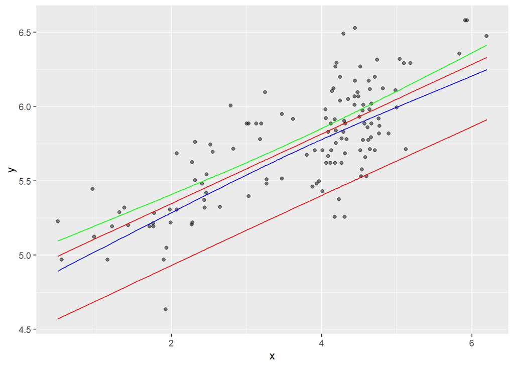

```r
###All together
g <- g + geom_line(data = df, aes(x = x, y = PIlower), colour = "red")
g1 <- g + geom_line(data = df, aes(x = x, y = PIupper), colour = "darkgreen")
g
```

```r
###HOW DO I ADD A LEGEND?????????
###I changed the name and now its kinda screwed up and I am not sure why...It also doesn't give me an error until I call the specific function, which feels problematic I won't lie...I fixed it because I am a genius.  Moral of the story, don't change names halfway thorough.
```

###Produce a point estimate and associated 90 percent PI for the longevity of a species whose brain weight is 800 gm.

```r
pi <- predict(m, newdata = data.frame(logBrain_Size_Species_Mean = 800), interval = "prediction",
    level = 0.9)
pi
```

```
##        fit      lwr      upr
## 1 192.1986 168.6955 215.7017
```

###estimate: 192.1986 for lower and upper: 168.6955, 215.7017

###Do you trust the model to predict observations accurately for this value of the explanatory variable? Why or why not? No? Because lots outside CI???–> We can’t trust this very much because our value are not in the range we predicted.

1. The length of these modules is my biggest challenge. I am the worlds slowest coder oh my goodness.
2. I found some helpful things online, but now I don’t think I did a great job annotating, because I am not positive what all I was doing.
3. I am not sure about the sample numbers I chose in number 1.
4. In general, I just need to go back over the modules again.
5. Is Z.prop.test the same as Z.test?
6. I can’t get the running thing to show up????

###Someone had told me on an earlier assignment that I could put descritions in the {r} on the top of my code, but when I do that it doesnt run anymore… ###I feel like I am relying really heavily on other peoples codes and help material that I find online.

*I know this assignment was a doozy. As far as the regression part goes, try to think about when you want to log transform the data (has to do with the distribution) and the interpretation of your beta values (think about your basic y=mx+b equation). Practicing ggplot will help you because then you can constantly check what your regression looks like. As far as ggplot goes, looking on the internet and other people’s code is honestly a great way to learn!*